# Notas de Aula - Introdução à Inferência Estatística

Jufln

# 1 Introdução a Inferência Estatística

A inferência estatística permite tirar conclusões sobre uma população a partir de uma amostra. Selecionar indivíduos aleatoriamente garante que todos tenham a mesma chance de serem incluídos, essencial para fazer inferências.

## 1.1 Objetivo

Fazer inferências sobre a população usando estatísticas da amostra.

### 1.1.1 Estatísticas da Amostra

| Estatística | Função |
| --- | --- |
| Média (X̄) | Média da amostra |
| Desvio Padrão (S) | Desvio padrão da amostra |

### 1.1.2 Parâmetros Populacionais

Média (μ) e desvio padrão (σ) da população.

## 1.2 Estatística Descritiva e Inferência

Estatísticas amostrais, como a média e o desvio padrão, são usadas para estimar os parâmetros populacionais correspondentes. Métodos adequados garantem que essas estimativas sejam representativas da população, permitindo fazer inferências confiáveis sobre ela a partir da amostra.

## 1.3 Verificação de Precisão

Centramento refere-se à precisão das estimativas amostrais próximas aos parâmetros populacionais, como média e variância. Viés indica a tendência de uma estimativa afastar-se sistematicamente do valor real do parâmetro, mesmo com aumento do tamanho da amostra. Um estimador não enviesado é essencial para garantir que as estimativas sejam centradas nos parâmetros populacionais corretos.

## 1.4 Medidas de Tendência Central

| Medida | Descrição |
| --- | --- |
| Média | Soma dos valores dividida pela quantidade. Representada por X̄. |
| Mediana | Valor que divide a amostra em duas partes iguais quando ordenada. |
| Moda | Valor mais frequente na amostra. Pode ser unimodal, bimodal ou multimodal. |

## 1.5 Distribuições e suas Estatísticas

| Tipo de Distribuição | Descrição |
| --- | --- |
| Distribuições Simétricas | Média, mediana e moda coincidem. |
| Distribuições Assimétricas | Média, mediana e moda em diferentes posições. |

### 1.5.1 Exemplo de Distribuição Normal

Média, mediana e moda coincidem.

## 1.6 Ferramenta R para Estatísticas

### 1.6.1 Computação no R

Definição da amostra e cálculo de média, mediana, moda, variância e desvio padrão.

#### 1.6.1.1 Funções do R

Uso de `mean()`, `median()`, e criação de funções para cálculos personalizados como moda.

## 1.7 Medidas de Espalhamento

| Medida | Descrição |
| --- | --- |
| Amplitude | Diferença entre o valor máximo e mínimo da amostra. |
| Variância | Soma das diferenças quadráticas de cada valor com a média, dividida por N-1. |
| Desvio Padrão | Raiz quadrada da variância, representando a distância média dos valores em relação à média. |
| Intervalo Interquartil (IQR) | Diferença entre o terceiro quartil (Q3) e o primeiro quartil (Q1). |

### 1.7.1 Aplicações no R

#### 1.7.1.1 Funções

- `range()`: Calcular a amplitude.
- `var()`: Calcular a variância.
- `sd()`: Calcular o desvio padrão.
- `quantile()`: Calcular quartis.
- Funções personalizadas para cálculos específicos como moda.

## 1.8 Anotações Descritivas da Aula

### 1.8.1 Conceito de Estimador

- **Média (X̄)**: variável aleatória centrada na média populacional (μ), estimador não enviesado.
- **Variância de X̄**: precisa ser examinada.

### 1.8.2 Estimadores da Variância

| Método | Descrição |
| --- | --- |
| Variância com N | Pode introduzir viés, subestimando a variância populacional. Exemplo: {1, 2, 3}, variância 0,67. |
| Variância com N-1 | Corrige o viés, resultando em estimador não enviesado da variância populacional (σ²). |

## 1.9 Simulação e Verificação

- População de 30 mil elementos repetidos {1, 2, 3}, média 2 e variância 0,67.
- 10.000 amostras de tamanho 2, cálculos de média e variância (N e N-1).
- Histograma das variâncias: N com média 0,33 (subestima), N-1 com média 0,66 (aproxima).

## 1.10 Para lembrar:

- Estimador não enviesado: Usar N-1 para estimar corretamente a variância populacional.
- Correção do viés: Essencial para estimativas precisas.
- Próximos passos: Exploração do intervalo de confiança e sua importância nas estimativas.

## 1.11 Exercício Prático

- Implementação do cálculo da variância não enviesada em R.
- Simulação com populações e amostras diferentes.

## 1.12 Recapitulando

- **Média (X̄)**: estimador não enviesado de μ.
- **Variância amostral**: N-1 no denominador evita viés.
- **Simulações**: Confirmam uso de N-1 para estimativas centradas na variância populacional.
- **Amostragem Aleatória**: Garantir igualdade de chances para inclusão na amostra.
- **Inferência Estatística**: Usar estatísticas amostrais para inferir parâmetros populacionais.

# 2 Estatísticas Descritivas

| Medida | Descrição |
| --- | --- |
| Média | Soma de todos os valores dividida pelo número de valores. |
| Mediana | Valor que divide os dados ordenados em duas partes iguais. |
| Moda | Valor que ocorre com mais frequência na amostra. |

## 2.2 Tipos de Distribuições

| Tipo de Distribuição | Descrição |
| --- | --- |
| Unimodal | Uma moda. |
| Bimodal | Duas modas. |
| Multimodal | Mais de duas modas. |
| Distribuição Simétrica | Média, mediana e moda coincidem. |
| Distribuição Assimétrica | Média, mediana e moda diferem. |

## 2.3 Medidas de Dispersão

| Medida | Descrição |
| --- | --- |
| Amplitude | Diferença entre o valor máximo e o mínimo. |
| Variância | Média das diferenças quadráticas dos valores em relação à média da amostra. |
| Desvio Padrão | Raiz quadrada da variância. |
| Intervalo Interquartil (IQR) | Diferença entre o terceiro quartil (Q3) e o primeiro quartil (Q1). |

## 2.4 Implementação em R

- Definir Amostra: `amostra <- c(101, 101, 113, 117, 187)`
- Cálculo da Média: `mean(amostra)`
- Cálculo da Mediana: `median(amostra)`
- Cálculo da Moda: Criar função personalizada.
- Cálculo do Range: `range(amostra)` e `diff(range(amostra))`
- Cálculo da Variância: `var(amostra)`
- Cálculo do Desvio Padrão: `sd(amostra)`
- Cálculo do IQR: `IQR(amostra)`

## 2.5 Aplicações e Observações

- A média é sensível a valores extremos, enquanto a mediana é mais robusta.
- Distribuições simétricas (como a normal) têm média, mediana e moda iguais.
- Para distribuições assimétricas, essas medidas tendem a se separar.
- Média aritmética é usada para dados normais; média geométrica é usada para dados multiplicativos, como taxas de retorno de investimentos.
- **Média Aparada**: Remove uma porcentagem dos valores mais extremos antes de calcular a média, utilizada para diminuir o impacto de outliers.

## 2.6 Coleta de Amostras e Distribuição de Médias

1. **Coleta de Números Diferentes:**
   - Pegamos diferentes números (exemplo: 1, 1; 1, 2; 1, 3; 2, 2; etc.)
   - Calculamos a média de cada combinação e geramos um histograma dessas médias.
2. **Distribuição do X Barra (Média das Amostras):**
   - A distribuição de X barra é simétrica e centrada em 2 (igual à média populacional).
   - X barra é um estimador não enviesado da média populacional, Mi, pois pode ter valores tanto acima quanto abaixo do verdadeiro valor com igual probabilidade.

# 3 O Teorema Central do Limite

O Teorema Central do Limite (TCL) é um conceito fundamental em estatística que estabelece que, independentemente da distribuição da população original, a distribuição das médias amostrais se aproxima de uma distribuição normal à medida que o tamanho da amostra (n) aumenta. Esse teorema é crucial porque permite inferências sobre a população com base em amostras, mesmo que a distribuição original não seja normal.

Para ilustrar o TCL, vamos realizar uma simulação em R. Suponha que temos uma população composta de apenas dois valores: 0 e 1. A tarefa é extrair amostras dessa população, calcular a média de cada amostra e observar a distribuição dessas médias.

Primeiro, criaremos um vetor em R para armazenar as médias (x̄) das amostras que iremos extrair:

```r
# Número de amostras a serem simuladas
num_amostras <- 5000

# Vetor para armazenar as médias das amostras
medias_amostrais <- numeric(num_amostras)
```

Em seguida, faremos 5000 amostragens da população com reposição e calcularemos a média de cada amostra:

```r
# Tamanho da amostra
n <- 25

# População de 0s e 1s
populacao <- c(0, 1)

# Simulação das 5000 amostras
set.seed(123)  # Definindo uma semente para reprodutibilidade
for (i in 1:num_amostras) {
  amostra <- sample(populacao, n, replace = TRUE)
  medias_amostrais[i] <- mean(amostra)
}
```

Agora, vamos visualizar a distribuição das médias amostrais utilizando um histograma:

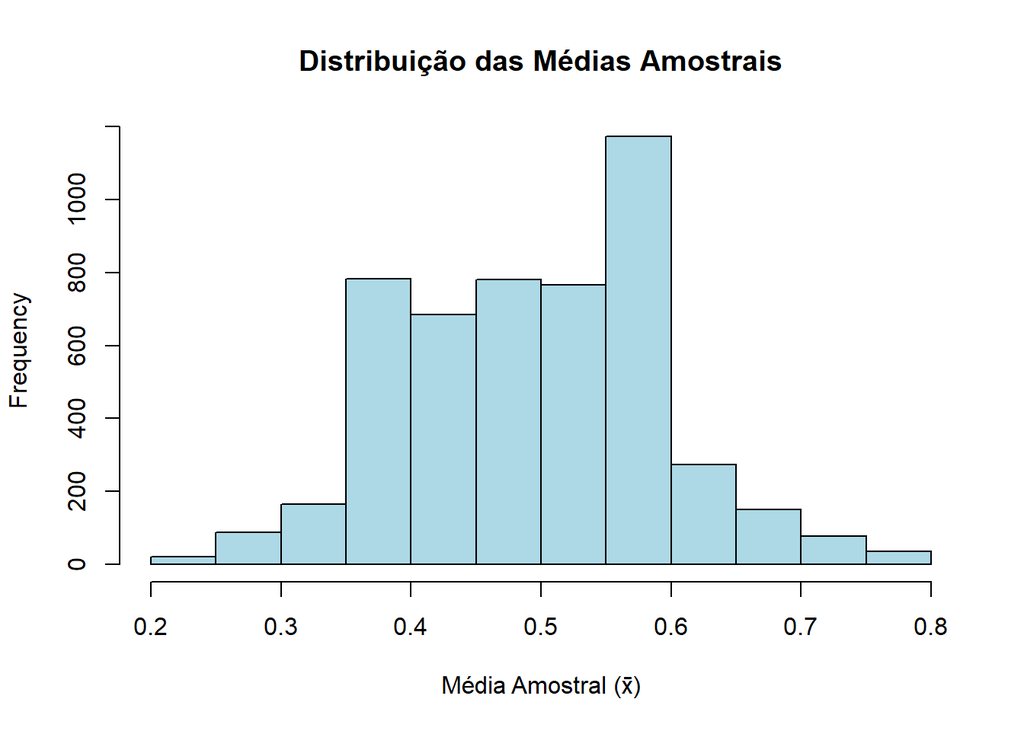

```r
# Histograma das médias amostrais
hist(medias_amostrais, breaks = 20, col = "lightblue", main = "Distribuição das Médias Amostrais", xlab = "Média Amostral (x̄)")
```

A média das médias amostrais deve se aproximar da média da população. Além disso, podemos calcular o desvio padrão das médias amostrais e compará-lo com o valor esperado, que é o desvio padrão da população dividido pela raiz quadrada do tamanho da amostra (σ/√n):

```r
# Média das médias amostrais
media_xbar <- mean(medias_amostrais)
media_xbar  # Aproxima de 0.5
```

```
## [1] 0.499
```

```r
# Desvio padrão das médias amostrais
sd_xbar <- sd(medias_amostrais)
sd_xbar  # Aproxima de σ/√n
```

```
## [1] 0.09934029
```

```r
# Desvio padrão esperado
sigma <- sqrt(0.25)  # σ para uma distribuição binomial
desvio_padrao_esperado <- sigma / sqrt(n)
desvio_padrao_esperado  # Aproxima de 0.1
```

```
## [1] 0.1
```

Podemos também explorar como variar o tamanho da amostra (n) afeta as médias e os desvios padrão:

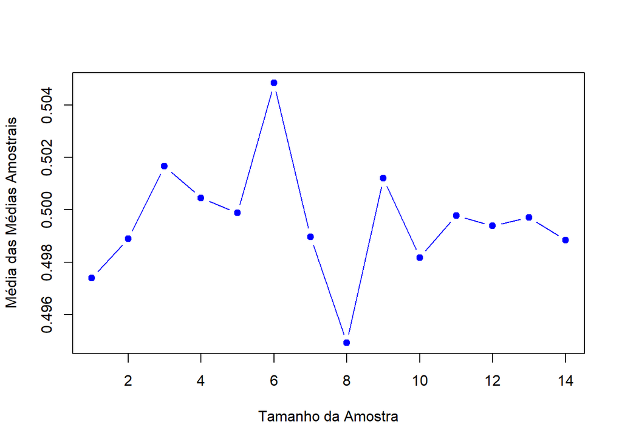

```r
# Vetor de tamanhos de amostra
n_vec <- 1:14

# Vetores para armazenar as médias e desvios padrão
medias_xbar <- numeric(length(n_vec))
desvios_xbar <- numeric(length(n_vec))

# Loop para diferentes tamanhos de amostra
for (count in 1:length(n_vec)) {
  n <- n_vec[count]

  # Simulação das amostras
  for (i in 1:num_amostras) {
    amostra <- sample(populacao, n, replace = TRUE)
    medias_amostrais[i] <- mean(amostra)
  }

  # Calcula média e desvio padrão
  medias_xbar[count] <- mean(medias_amostrais)
  desvios_xbar[count] <- sd(medias_amostrais)
}

# Plotando as médias
plot(n_vec, medias_xbar, type = "b", col = "blue", pch = 19, xlab = "Tamanho da Amostra", ylab = "Média das Médias Amostrais")
```

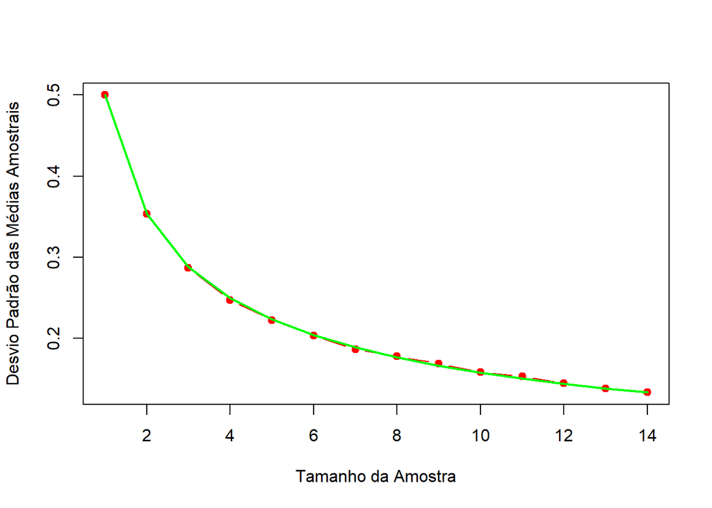

```r
# Plotando os desvios padrão
plot(n_vec, desvios_xbar, type = "b", col = "red", pch = 19, xlab = "Tamanho da Amostra", ylab = "Desvio Padrão das Médias Amostrais")
lines(n_vec, sigma / sqrt(n_vec), col = "green", lwd = 2)  # Linha teórica
```

Assim, o TCL nos garante que, mesmo que a população original não siga uma distribuição normal, as médias das amostras de tamanho suficientemente grande seguirão. Isso permite fazer inferências estatísticas robustas em uma ampla gama de cenários.

# 4 Distribuição t e Intervalos de Confiança

Os graus de liberdade são colocados nas linhas e os valores de probabilidade nas colunas. A integral de menos infinito até um determinado valor de $t$ está associada a uma probabilidade específica, como 60%, 70%, 80%, etc. Quando o grau de liberdade é muito grande, a distribuição $t$ se aproxima da distribuição normal. Assim, podemos procurar os valores de probabilidade associados aos valores de $t$ na tabela $z$, pois eles são semelhantes à tabela $t$ quando o grau de liberdade é infinito.

À medida que o grau de liberdade diminui, os valores de $t$ se afastam de zero, tornando o intervalo de confiança mais largo. Com uma amostra pequena, ou seja, com um grau de liberdade menor, o intervalo de confiança será mais largo do que com uma amostra maior. Isso ocorre por duas razões: a fórmula do erro padrão inclui a raiz de $n$ e, além disso, o valor de $t$ para graus de liberdade menores será maior.

Vamos considerar um exemplo prático. Para uma amostra pequena, com $n$ menor que 30, é obrigatório usar a distribuição $t$. Mesmo que a distribuição $t$ se aproxime da normal quando o grau de liberdade é alto, é preferível usar a distribuição $t$ para corrigir o grau de liberdade.

Por exemplo, se temos uma amostra de 10 elementos, com média de 8,7 e desvio padrão de 2, e queremos calcular o intervalo de confiança de 95%, o primeiro passo é calcular o erro padrão. Em seguida, procuramos na tabela $t$ a probabilidade associada a 95%. Como 95% corresponde a 97,5% em um intervalo de duas caudas, consultamos a tabela $t$ com o grau de liberdade $n-1$, que neste caso é 9. O valor correspondente de $t$ é encontrado e usado para calcular o intervalo de confiança.

A interpretação correta de um intervalo de confiança é que se você repetir o experimento muitas vezes, 95% dos intervalos calculados incluirão a verdadeira média da população. Não faz sentido afirmar que há 95% de probabilidade de que o intervalo de confiança inclua a verdadeira média, pois a média da população é uma constante e não varia. O que varia é o intervalo calculado com base na média amostral.

Métodos de reamostragem, como o bootstrap, podem ser usados para calcular intervalos de confiança sem depender de distribuições teóricas específicas. No procedimento bootstrap, você amostra com reposição da amostra original, calcula a estatística de interesse (como a média), e repete o processo muitas vezes. Os percentis 2,5% e 97,5% dessas estatísticas reamostradas fornecem o intervalo de confiança.

Por exemplo, se encontramos 260 peças defeituosas em uma amostra de 500, o intervalo de confiança de 95% para a proporção pode ser calculado usando tanto métodos teóricos quanto bootstrap. A função `t.test` do R pode ser usada para calcular o intervalo de confiança de forma rápida. O método bootstrap, por sua vez, envolve amostrar repetidamente a partir da amostra original e calcular os percentis das estatísticas para obter o intervalo de confiança desejado.

No caso de uma amostra com média de 8,7 e desvio padrão de 2, o uso de funções nativas do R para calcular o intervalo de confiança pode ser desafiador se você não tiver a amostra completa, apenas as estatísticas. A solução é simular uma amostra a partir das estatísticas fornecidas e usar métodos como o bootstrap para calcular o intervalo de confiança.

# 5 Teste de Hipóteses

## 5.1 Resumo do processo

**1. Passos do Teste de Hipótese:** - **Estruturação das Hipóteses**: - **Hipótese Nula (H0)**: Declara que não há efeito ou diferença significativa. - **Hipótese Alternativa (H1)**: Declara que há um efeito ou diferença significativa. - **Definição da Distribuição da Hipótese Nula**: - Usar a média ($\mu$) e o erro padrão ($\sigma/\sqrt{N}$) para construir a distribuição. - **Identificação das Áreas de Aceitação e Rejeição**: - Determinar a área de aceitação e rejeição com base no nível de significância ($\alpha$, geralmente 5%). - **Condução do Teste de Significância**: - Verificar onde a evidência empírica (valor observado) cai, se na área de aceitação ou de rejeição da hipótese nula. - **P-Valor**: - Se o p-valor for maior que 5%, aceitamos a hipótese nula (significância baixa). - Se o p-valor for menor que 5%, rejeitamos a hipótese nula (significância alta).

**2. Uso do R para Testes de Hipótese:** - **Simulação de Dados**: - Gerar uma amostra com média e desvio padrão desejados, por exemplo, média de 618 e desvio padrão de 100. - Escalar os dados para ter a média e desvio padrão desejados. - **Teste Unicaudal e Bicaudal**: - **Teste Unicaudal**: Verifica se a média da amostra é significativamente maior ou menor que a média da hipótese nula. - **Teste Bicaudal**: Verifica se a média da amostra é significativamente diferente da média da hipótese nula (maior ou menor). - **Função `t.test()`**: - Usada para realizar o teste de hipótese no R, fornecendo o valor de T, o grau de liberdade e o p-valor. - **Exemplo no R**: - Comparar uma amostra de 100 alunos com uma média de 618 contra uma média hipotética de 600, usando `t.test()` para calcular o p-valor.

**3. Cálculo Manual:** - **Definição das Hipóteses**: - Hipótese nula: As médias das populações são iguais. - Hipótese alternativa: As médias das populações são diferentes. - **Construção da Distribuição**: - Usar a média e o erro padrão para definir a distribuição. - **Identificação dos Valores Críticos**: - Calcular valores críticos com base na distribuição T para determinar as regiões de aceitação e rejeição. - **Comparação do Valor Observado**: - Verificar se o valor observado (média da amostra) cai dentro da área de aceitação ou rejeição. - **Correção do P-Valor**: - Ajustar o p-valor se necessário para garantir que ele esteja dentro de um intervalo plausível.

**4. Comparação dos Resultados:** - Verificar se os resultados do teste manual coincidem com os resultados obtidos usando a função nativa do R (`t.test()`), garantindo a precisão dos cálculos.

# 6 Teste de Hipótese - aula 1

- **Distribuição Normal:** Modelo de probabilidade para dados contínuos, caracterizado pela forma de sino.
- **Hipótese Nula (H0):** Afirmação inicial que se deseja testar, geralmente de que não há efeito ou diferença.
- **Hipótese Alternativa (H1):** Afirmação que se deseja provar, indicando um efeito ou diferença.
- **Nível de Significância (α):** Probabilidade máxima aceitável para rejeitar a hipótese nula quando ela é verdadeira (ex: 5% ou 0,05).
- **P-valor:** Probabilidade de observar um resultado tão extremo ou mais extremo que o observado, dado que a hipótese nula é verdadeira.
- **Teste de Cauda Única:** Teste usado quando a hipótese alternativa é direcional (ex: maior ou menor).
- **Teste de Cauda Dupla:** Teste usado quando a hipótese alternativa é não direcional (diferente).
- **Distribuição Z:** Distribuição normal padrão com média 0 e desvio padrão 1, usada para padronizar valores.
- **Valor Crítico (Z Crítico):** Valor de Z que corresponde ao nível de significância (α).
- **Intervalo de Confiança:** Intervalo que contém o valor verdadeiro da média com uma certa probabilidade (1 - α).

## 6.1 Exemplo em R: Teste de Hipótese para Média de Notas

Vamos supor que temos uma amostra de 30 alunos de um curso preparatório para o ENEM. Queremos testar se a média das notas dos alunos é significativamente maior que 600 pontos. Utilizaremos um nível de significância de 5% (α = 0,05) e faremos um teste de cauda única.

```r
# Dados da amostra
notas <- c(620, 630, 610, 615, 625, 640, 605, 620, 635, 620,
           610, 600, 615, 630, 625, 620, 635, 640, 615, 630,
           620, 625, 610, 635, 640, 620, 615, 630, 620, 625)

# Parâmetros do teste
n <- length(notas)  # Tamanho da amostra
media_amostral <- mean(notas)  # Média da amostra
desvio_padrao_amostral <- sd(notas)  # Desvio padrão da amostra
media_populacional <- 600  # Média sob a hipótese nula
alpha <- 0.05  # Nível de significância

# Cálculo do estatístico de teste (Z)
z <- (media_amostral - media_populacional) / (desvio_padrao_amostral / sqrt(n))

# Cálculo do p-valor para teste de cauda única (maior)
p_valor <- pnorm(z, lower.tail = FALSE)

# Valor crítico para o nível de significância de 5%
z_critico <- qnorm(1 - alpha)

# Resultados
cat("Média da amostra:", media_amostral, "\n")
```

```
## Média da amostra: 622.6667
```

```r
cat("Desvio padrão da amostra:", desvio_padrao_amostral, "\n")
```

```
## Desvio padrão da amostra: 10.48261
```

```r
cat("Estatístico Z:", z, "\n")
```

```
## Estatístico Z: 11.84347
```

```r
cat("P-valor:", p_valor, "\n")
```

```
## P-valor: 1.163125e-32
```

```r
cat("Valor crítico Z para α =", alpha, ":", z_critico, "\n")
```

```
## Valor crítico Z para α = 0.05 : 1.644854
```

```r
# Decisão do teste
if (p_valor < alpha) {
  cat("Rejeita-se a hipótese nula. Há evidências suficientes para afirmar que a média das notas dos alunos é maior que 600 pontos.\n")
} else {
  cat("Não se rejeita a hipótese nula. Não há evidências suficientes para afirmar que a média das notas dos alunos é maior que 600 pontos.\n")
}
```

```
## Rejeita-se a hipótese nula. Há evidências suficientes para afirmar que a média das notas dos alunos é maior que 600 pontos.
```

### 6.1.2 Observações Importantes

- O teste de hipótese é útil para decisões baseadas em dados, mas deve ser interpretado com cuidado.
- O p-valor indica a probabilidade de obter um resultado tão extremo quanto o observado, assumindo que a hipótese nula é verdadeira, e não a probabilidade da hipótese alternativa ser verdadeira.
- Considerar o tamanho da amostra e a relevância prática dos resultados é essencial antes de tomar uma decisão final.